# Finale RG (il y a longtemps) : Stan Wawrinka

Alain Guillet

21 avril 2023

# 1 Consignes

Vous devez refaire ce document à l’identique : sections, mise en forme, code R visible ou pas, tables et figures et date pouvant se mettre à jour quand on compile le document. Il doit également y avoir un paramètre permettant de changer le joueur, « Rafael Nadal » ou « Stan Wawrinka », dans l’entête du document (si vous n’y arrivez pas, écrivez le document pour un joueur fixé). Enfin, notez que par défaut, les figures et les tables doivent être centrées et le code caché, que les graphiques doivent par défaut utiliser le thème *theme_minimal* et qu’on a utilisé le thème *yeti* ainsi qu’une table des matières à un seul niveau.

Quand vous avez terminé, vous devez poster votre travail sur RPubs et déposer votre fichier Rmd sur Moodle en indiquant avant la première section le lien de votre publication sur RPubs. Si vous n’avez pas encore d’identifiant pour RPubs, il est encore temps de le créer.

Remarques :

- La section « Consignes » ne doit pas être reprise dans votre document final, pas plus que les remarques écrites en italique qui sont là pour vous guider.
- Il y a parfois plusieurs manières d’arriver au même résultat. Choisissez une manière et ne les donnez pas toutes.
- Essayez d’être le plus proche possible du résultat à défaut de le répliquer totalement.

# 2 Importation des données

```r
load("Data/MenRG_Final.Rda")
```

Le data frame MenRG_Final a 151 lignes et ses colonnes sont match_id, year, slam, match_num, player1, player2, Circuit, ElapsedTime, SetNo, P1GamesWon, P2GamesWon, SetWinner, GameNo, GameWinner, PointNumber, PointWinner, PointServer, Speed_KMH, Rally, P1Score, P2Score, P1PointsWon, P2PointsWon, P1Ace, P2Ace, P1Winner, P2Winner, P1DoubleFault, P2DoubleFault, P1UnfErr, P2UnfErr, P1NetPoint, P2NetPoint, P1NetPointWon, P2NetPointWon, P1BreakPoint, P2BreakPoint, P1BreakPointWon, P2BreakPointWon, Speed_MPH, P1BreakPointMissed, P2BreakPointMissed, ServeIndicator, ServeNumber, WinnerType, WinnerShotType, P1DistanceRun, P2DistanceRun, RallyCount, ServeWidth, ServeDepth, ReturnDepth, PointServer_ServeNumber_PointWinner.

Les deux joueurs concernés par le match sont :

- Rafael Nadal
- Stan Wawrinka

*Remarque : Le nombre de lignes, les noms des colonnes et les noms des deux joueurs doivent être obtenus à l’aide de commandes R.*

# 3 Description des données

Cette section décrit les différentes variables du jeu de données qui seront utiles par la suite.

| Nom | Description |
| --- | --- |
| P1DistanceRun | Distance parcourue par le joueur |
| PointNumber | Numéro du point |
| PointServer | Serveur du point |
| ServeDepth | Profondeur du service |
| ServeNumber | Numéro du service |
| ServeWidth | Direction du service |
| Speed_KMH | Vitesse du service en km/h |

NCTL et CTL signifient respectivement « Loin de la ligne de fond de carré de service » et « Près de la ligne de fond de carré de service ». B, BC, BW, C et W dans ServeWidth indique à quel point le service est en direction du joueur.

Voici un aperçu des données :

| P1DistanceRun | PointNumber | PointServer | ServeDepth | ServeNumber | ServeWidth | Speed_KMH |
| --- | --- | --- | --- | --- | --- | --- |
| 7.765 | 1 | Rafael Nadal | NCTL | Second serve | BC | 143 |
| 17.768 | 2 | Rafael Nadal | CTL | First serve | BC | 193 |
| 1.448 | 3 | Rafael Nadal | NCTL | Second serve | BW | 164 |
| 18.172 | 4 | Rafael Nadal | NCTL | Second serve | BW | 161 |
| 3.53 | 5 | Stan Wawrinka | CTL | First serve | W | 178 |
| 23.989 | 6 | Stan Wawrinka | NCTL | Second serve | BW | 147 |
| 1.36 | 7 | Stan Wawrinka | NCTL | First serve | C | 207 |
| 5.35 | 8 | Stan Wawrinka | NCTL | First serve | BC | 194 |
| 13.289 | 9 | Stan Wawrinka | NCTL | Second serve | C | 172 |
| 5.192 | 10 | Rafael Nadal | NCTL | Second serve | BC | 160 |

[output cut: 141 more lines]

# 4 Comparaison des vitesses de service entre les serveurs

## 4.1 Distribution de la vitesse des services

Pour cela, on peut regarder les principaux quantiles, la moyenne et l’écart-type.

|  | Rafael Nadal | Stan Wawrinka |
| --- | --- | --- |
| Minimum | 142.00 | 141.00 |
| p25 | 157.00 | 157.25 |
| Moyenne | 173.65 | 172.85 |
| Médiane | 180.00 | 172.50 |
| p75 | 186.00 | 188.00 |
| Maximum | 198.00 | 212.00 |
| Ecart-Type | 16.43 | 19.98 |

## 4.2 Distance parcourue en fonction du serveur et de qui a gagné le point

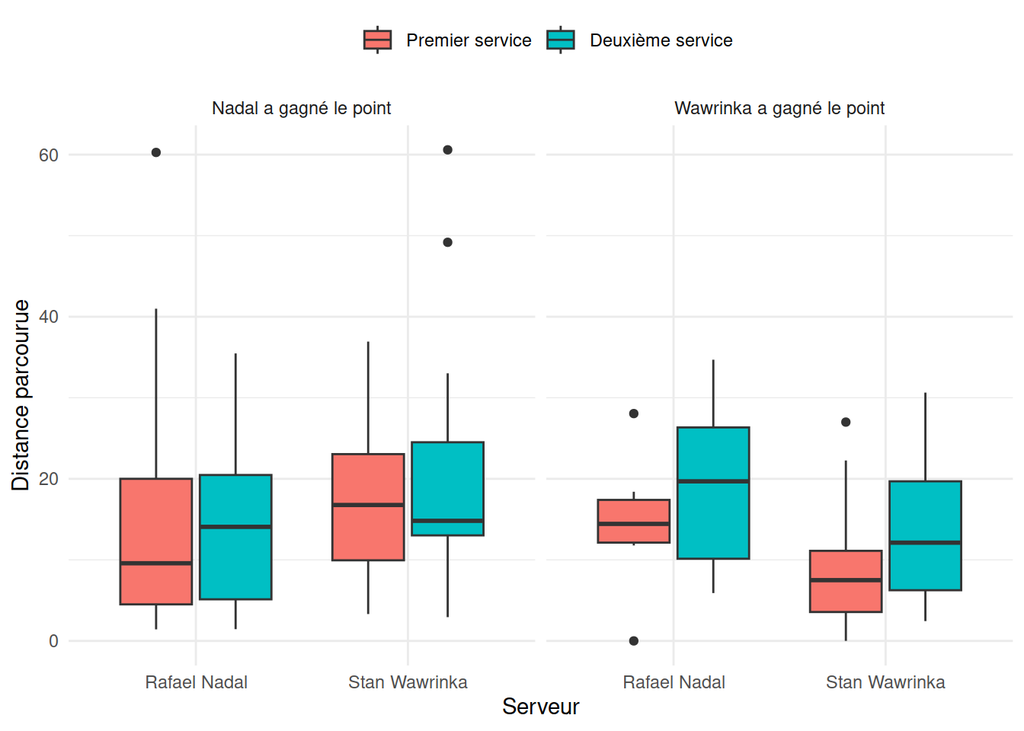

## 4.3 Vainqueur du point en fonction du serveur

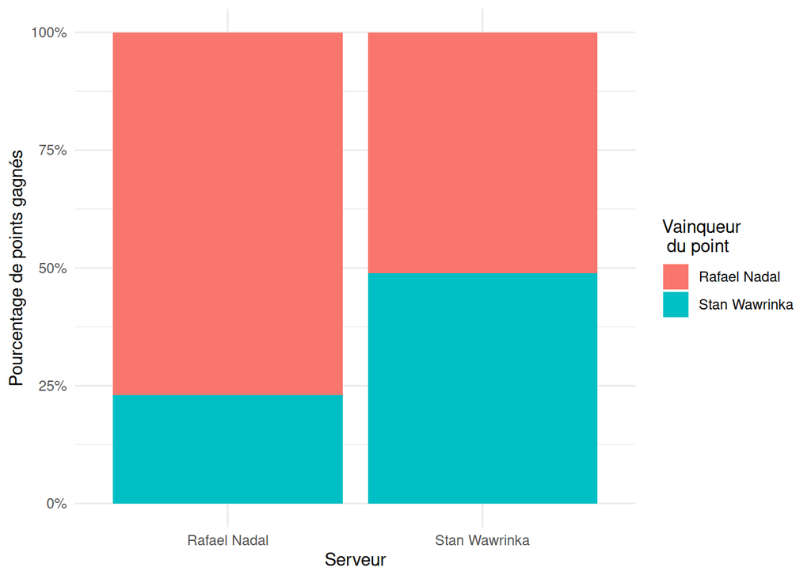

# 5 Uniquement pour Stan Wawrinka

*Remarque : Le nom du joueur vient d’une commande R.*

On sélectionne les lignes uniquement telles que le serveur est l’un des deux joueurs et telles que `ServeWidth != "" & ServeDepth != ""`. Ici, on le fait pour Stan Wawrinka.

## 5.1 Evolution au cours du match

Pour savoir s’il y a une évolution de la vitesse, on réalise un *scatter plot* représentant la vitesse du service en fonction du nombre de points. On sépare les premier et deuxième services.

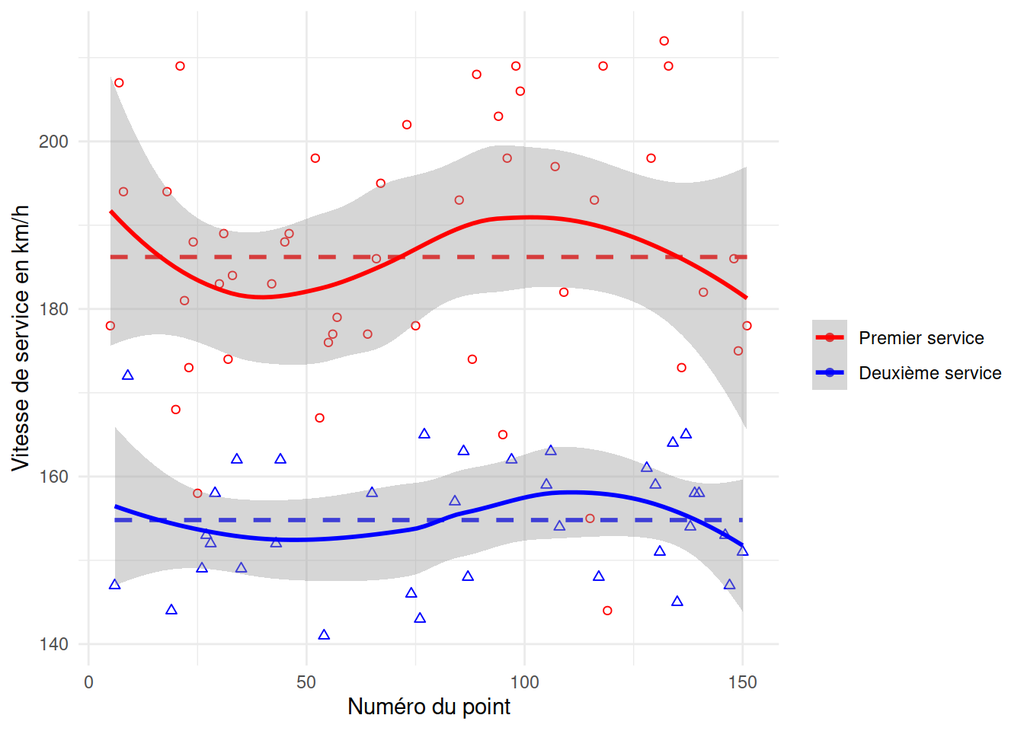

Vitesse du service de Stan Wawrinka lors de la finale de Roland Garros

*Remarques : La droite horizontale est la moyenne des premier et deuxième services respectivement, l’autre est une régression locale (*loess*). et la phrase sous la figure est un caption qui dépend du nom du joueur.*

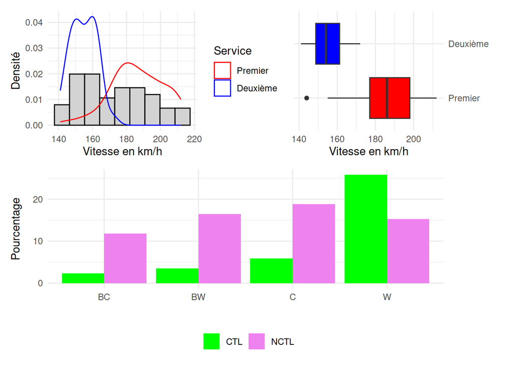